# Hey Hollywood, Where are the Women?

Vatsala Ramanan, Margaret Bassney, and Emma Kornberg

Date: May 5, 2019

[figure not shown]

In the past twenty years, women in the United States have made great strides towards equality and representation. In 2007, Representative Nancy Pelosi became the first female speaker of the House, while in 2016, Hillary Clinton became the first female presidential candidate nominated by a major political party. In 2009, the Lilly Ledbetter Fair Pay Restoration Act helped women file government complaints for pay discrimination, and in 2013, women first entered combat positions in the U.S. military. With all these monumental successes, one would expect a reflection of this with positive female representation in popular media and increased appreciation for such forms of entertainment. Does this hold true in reality?

Let us consider the top ten PG-13 rated movies produced in the years 2000, 2008 and 2016, from the [Internet Movie Database](https://www.imdb.com/pressroom/about/), or the imdb. Given that media representation most affects young, developing minds, PG-13 rated movies are integral to this investigation as their target audience, middle school-aged teenagers, are beginning to explore their sexuality and identity. With this, female representation in popular media is deeply influential in the [development of the sense of self] (https://www.huffpost.com/entry/why-on-screen-representation-matters_n_58aeae96e4b01406012fe49d). Furthermore, the way women are represented in these movies affects how young females view themselves and how young males view them, bringing the issue into the real world. As we examine today’s media representation and its change over time, the three years of focus are key because they are each roughly a generation apart, and can thus help assess the progress made.

## How do we know if a movie truly represents women?

Female representation is a rather subject concept. So, to determine whether movies portray women with substantial importance, we refer to the Mako Mori Test. Named after a Pacific Rim character, the Mako Mori test proposes an alternative to the popular Bechdel test. This test focuses not on women conversing with each other as the Bechdel test does, but on the story of at least one woman. The rules of the test are that (1) the movie must have at least one female character, (2) that character must get her own narrative arc, and (3) the arc cannot be dependent on the man’s story. While people still argue over whether or not “Pacific Rim” was feminist or not, the test has great potential. For example, Emma Stone’s character from the 2016 movie La La Land passes the test as she has an independent narrative arc which focuses on her ambitions to be an actor. Here’s a scene from the movie showing this:

[video not shown]

However, the movie O Brother Where Art Thou? fails the test. As shown in the scene below, the women do nothing more than seduce the male protagonists of the movie and do not have independent goals and aims. In this, the great actress Holly Hunter plays Penny, a character who is seen as property by the male character Everett.

[video not shown]

## What does the data tell us?

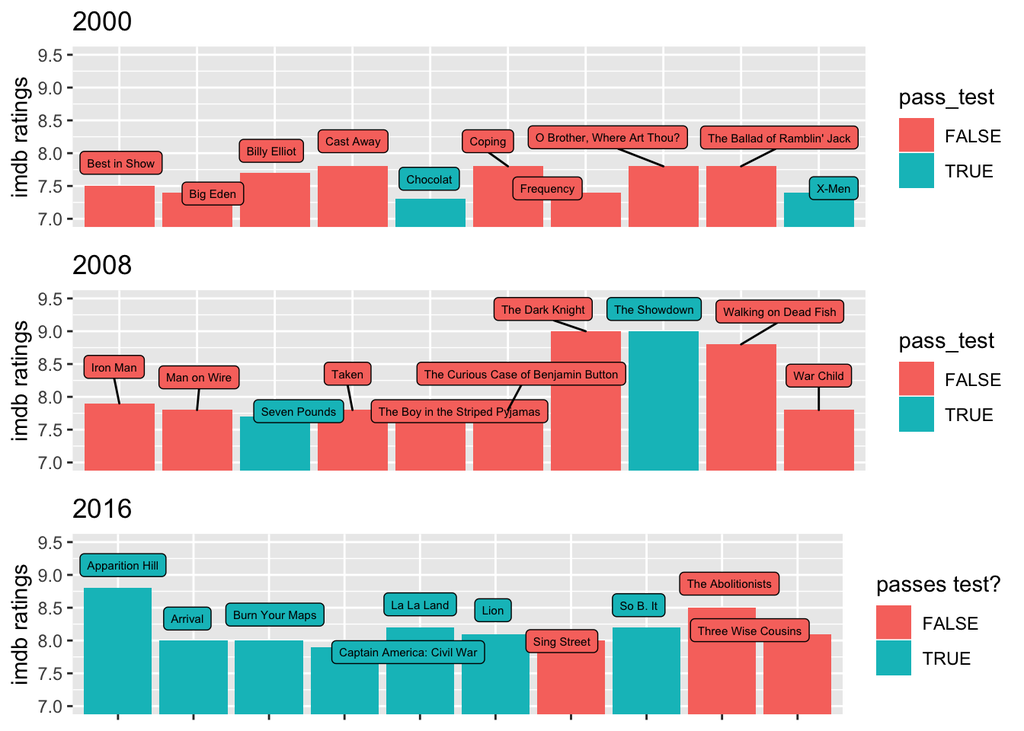

According to the imdb data, the early 2000’s were not the kindest years for women with the media representation of the time. In the year 2000, the few top ten movies that do portray female representation are the lowest rated. Every other top ten movie that year is male focused and depicts women as objects.

However, eight years later, female representation begins to improve, if marginally. In 2008, The Showdown is one of two films that passes the test that year. It shares equal ratings with The Dark Knight, another 2008 film that does not pass the test. The only other movie that year to pass the test was Seven Pounds and it experienced the lowest ratings among the top ten movies.

Finally, another eight years later, the representation of women improves dramatically. In 2016, not only do the majority of the top ten IMDB rated movies pass the test, but these movies are also the movies with the highest ratings. While the majority of the 2008 movies that failed the test were violent, in 2016, the majority of the movies that did pass the test were nonviolent.

At this point, we must take into account that how we interpret our data may be influenced by the fact that, as time goes on, technology advances. With this, higher quality movies are being produced and, in turn, ratings increase. Thus, past movies with positive representation of women may not have been been rated as highly due to the lower production quality.

Although we see the representation of women rise in 2016, progress is still necessary. With every movie we examined, men were always positively represented. This shows that it is possible to consistently positively represent one gender identity and means that it can and should be done for woman as well.